# ICAnet tutorial

Weixu Wang

ICAnet can run on both single batch and multi-batch datasets. For each datasets, we run ICA independently, further, we cluster the all independent components, find shared and specific expression programs, and combine with PPI to perform clustering. In this tutorial, I gonna used cell line dataset provided by 10X Genomics as illustate dataset to show how to use ICAnet to perform batch effect correction and clustering. The source dataset(including gene expression dataset, cell annotation, and PPI network) can be download from https://github.com/WWXkenmo/MouseGerm. We load the dataset at the first,

```r
setwd("/mnt/data4/weixu/MCTA/MouseSperm")
library(Seurat)
library(cowplot)
source("ICAnet_functions.R")
PPI <- readRDS("PPI_for_cell_line.RDS")
all.data <- readRDS("cell_line_exp.RDS")
ID <- read.table("ID_for_cell_line.txt",header=TRUE,row.names=1,stringsAsFactors = FALSE)
```

check the dimension for cell line dataset

```r
dim(all.data)
```

```
## [1] 16602  8783
```

## Create Seurat Object

ICAnet required user to save their scRNA-seq dataset into Seurat object, meanwhile, the Seurat object also need to have ‘batch’ and ‘celltype’ ID. In this tutorial, the scRNA-seq dataset has been preprocessed.

```r
head(ID)
```

|  | cell.type | batch |
| --- | --- | --- |
| AAACATACACTGGT | 293t cell | 293t cell |
| AAACATACAGACTC | 293t cell | 293t cell |
| AAACATTGACCAAC | 293t cell | 293t cell |
| AAACATTGAGGCGA | 293t cell | 293t cell |
| AAACATTGGGACTT | 293t cell | 293t cell |
| AAACCGTGATTTCC | 293t cell | 293t cell |

```r
all.data <- CreateSeuratObject(counts = all.data, project = "cell.all", min.cells = 0)
all.data$celltype <- ID$cell.type
all.data$batch <- ID$batch
all.data <- NormalizeData(all.data, normalization.method = "LogNormalize", scale.factor = 10000)
```

We first run the original workflow, using PCA to perform embedding at first then used UMAP to visualize the results.

```r
all.data <- ScaleData(all.data)
all.data <- RunPCA(all.data, features = rownames(all.data), npcs = 20, reduction.name = "PCA", reduction.key = "PCA_", verbose = FALSE)
```

According to ElbowPlot, we selected top15 PCs

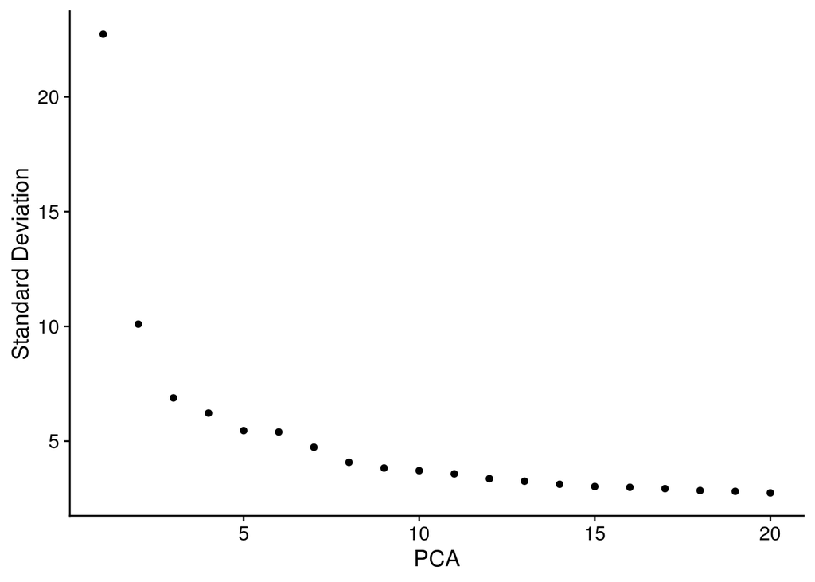

```r
ElbowPlot(all.data,reduction = "PCA")
```

```r
all.data <- RunUMAP(all.data, reduction = "PCA", dims = 1:15, reduction.name = "UMAP",  reduction.key = "UMAP_")
```

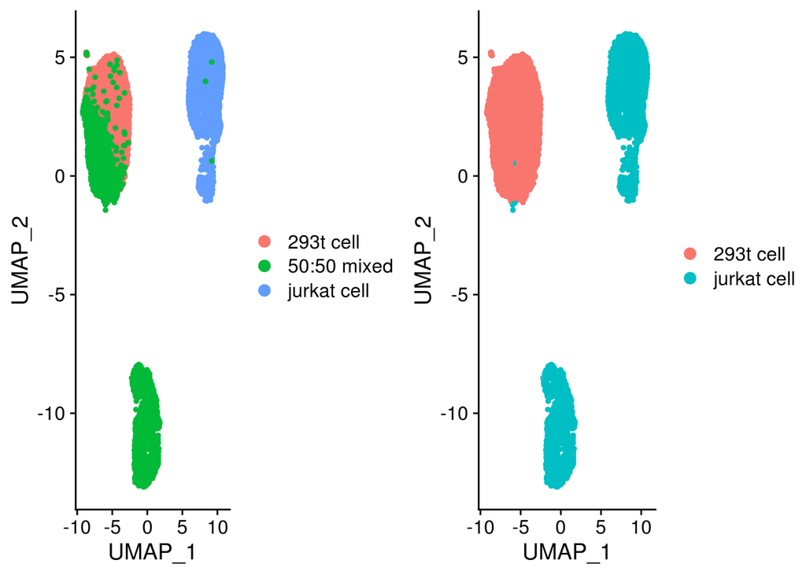

```r
p1 <- DimPlot(all.data, reduction = 'UMAP', pt.size = 1, group.by = 'batch')
p2 <- DimPlot(all.data, reduction = 'UMAP', pt.size = 1, group.by = 'celltype')
plot_grid(p1, p2)
```

As you can see, a part of cells from “50:50 mixed” are seperated as a independent group(left panel), while this part of cells are actually belong to jukart cells(right panel), therefore the original dataset exists batch effects.

## Run ICAnet to correct batch effect

ICAnet is consistent of three steps, the first step is to decompose each batch of single cell gene expression matrix into a number of independent component, the number of component was choosed based on random matrix theory.

```r
ica <- ICAcomputing(obj = all.data,RMT=TRUE,ICA.type = "JADE")
```

```
## [1] "batch 1 Indepdent Component Analysis"
## [1] "emmm...centering..."
## [1] "Done Centering"
## [1] "Using RMT to estimate number of module"
```

```
## [1] "RMT estimate 6 expression programm"
## [1] "Running 2th-step of RMT...(Recommend for integrating different platform)"
```

```
## [1] "Two step RMT estimate 3 expression programm"
## [1] "batch 2 Indepdent Component Analysis"
## [1] "emmm...centering..."
## [1] "Done Centering"
## [1] "Using RMT to estimate number of module"
## [1] "RMT estimate 7 expression programm"
## [1] "Running 2th-step of RMT...(Recommend for integrating different platform)"
```

```
## [1] "Two step RMT estimate 2 expression programm"
## [1] "batch 3 Indepdent Component Analysis"
## [1] "emmm...centering..."
## [1] "Done Centering"
## [1] "Using RMT to estimate number of module"
## [1] "RMT estimate 8 expression programm"
## [1] "Running 2th-step of RMT...(Recommend for integrating different platform)"
```

```
## [1] "Two step RMT estimate 3 expression programm"
```

```r
head(ica$ica.pooling)
```

```
##          293t cell-1 293t cell-2 293t cell-3 50:50 mixed-1 50:50 mixed-2
## 7SK.2    -0.18068420 -0.08114175  0.03944666   -0.01833748     0.2412057
## A1BG     -1.86723333 -0.62728335 -0.20187972   -1.58745373     2.1830933
## A1BG-AS1 -0.35676662 -0.15649454  0.15070714   -0.01155930     0.2564616
## A2M-AS1  -0.16014356 -0.10913912  0.05514712   -0.01526717     0.2752598
## A4GALT   -0.05843392  0.01175534  0.11732078    0.04645104     0.1957072
## AAAS      1.49244298 -0.17560096 -0.11327307   -0.03039927    -1.4349816
##          jurkat cell-1 jurkat cell-2 jurkat cell-3
## 7SK.2       -0.1580621    0.18584382    0.05559095
## A1BG        -3.1460765    1.39732805   -0.21896769
## A1BG-AS1    -0.5255411    0.09140577   -0.07379551
## A2M-AS1     -0.1415866    0.21466110    0.09347620
## A4GALT      -0.1415866    0.21466110    0.09347620
## AAAS         0.9239377   -0.72184542    0.05644844
```

**Important parameters are as follows**:

- *ICA.type* character value specifying the type of ICA used in decompose expression matrix, we provided three type ICA 1)JADE; 2)fastICA; 3)MineICA, in which MineICA is multiple running of fastICA, and select out the consensus ICs, therefore it require a long time for running. We recommend to use JADE for independent component analysis.
- *nc.vec* integer value specifying the number of independent component for each batch. Higher nc.vec is recommended for datasets with more substracture. Because this is an unsupervised, exploratory analysis, there is no “right” values for nc.vec. the users could used random matrix theory to estimate the number of components.
- *global.mode* boolean value indicate whether performing independent component analyais on whole datasets, it only require to specific one parameters *nc.global.mode*. Using global mode could correct both continues and discrete technique effects.
- *nc.global.mode* integer value specifying the number of independent component for the whole scRNA-seq dataset.
- *two.stage* blooean value indicate whether to used ICA+RMT(two-step RMT) to estimate the number of latent independent components, as show in our manuscript, using RMT+ICA would present better estimation of the number of cell types compare with merely using RMT when facing high dimensional dataset, we recommended to use this parameters when perform batch effect correction on the data with sample size > 5000
- *two.stage.ICA* character values indicate the type of ICA used in two-stage estimation, we recommend to use “JADE” when sample size is not so large, when encounter with the data which has large samples(cells), we recommend to use “FastICA”

The result is a number of independent components, to learn basel components from these components, we used Partitioning Around Medoids clustering method to cluster the components and select the meriods as the “basal components”

```r
Ica.filter <- CrossBatchGrouping(ica$ica.pooling)
```

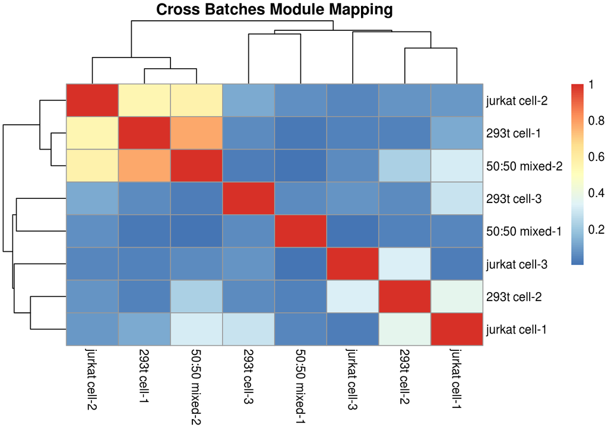

```
## Identify3 patterns
```

**Important parameters are as follows**:

- *cor* character value indicate the type of correlation used to cluster source ICs from different batches. We provided two type of correlations: pearson and spearman
- *W.top* the weight threshold to define “activated” genes which their attributes values were used to compare the similarity between different ICs.

Further, we could learn ‘activated’ modules through combine ICA-score and PPI network, the user could download PPI network through getPPI_String functions provided by SCORE R packages. For convenience, we have prepared the pre-processed STRING PPI network which are ready to use. The STRING PPI networks is generated through filtering the interactions which their combine score is below 600.

```r
cat('Running ICAnet')
```

```
## Running ICAnet
```

```r
all.data <- RunICAnet(all.data,Ica.filter$ica.filter,PPI.net = PPI)
```

```
## [1] 551
## [1] 551
## [1] "num:303"
```

```
## Quantiles for the number of genes detected by cell:
## (Non-detected genes are shuffled at the end of the ranking. Keep it in mind when choosing the threshold for calculating the AUC).
```

```
##     min      1%      5%     10%     50%    100%
## 2002.00 2112.82 2438.00 2654.20 3346.00 4997.00
```

```
## Using 6 cores.
```

```
## Using 6 cores.
```

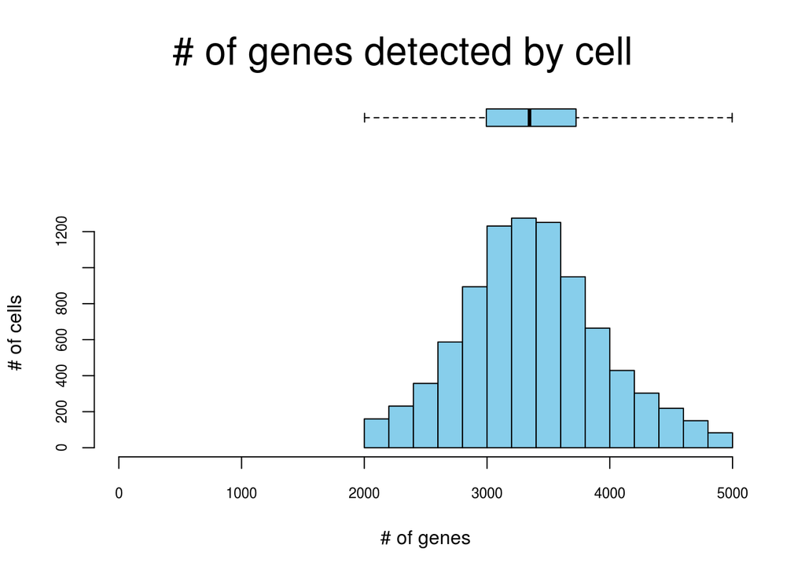

**Important parameters are as follows**:

- *W.top* integer value specifying the threshold which used to define “activated” genes. The genes which their attributes value are larger than the W.top*derivation from mean will be selected as the activated genes.
- *PPI.net* character value, the protein-protein interaction matrix. if no specific PPI matrix(PPI.net=NULL), ICAnet would downloaded “String” or “BioGrid” PPI network, the functions are dependent on R.SCORE packages.
- *small.size* integer values, filtered the modules which their gene number is smaller than *small.size*
- *nMC* integer values, specifying the number of bootstrapping when calculate the statistical significance for each module.

ICAnet would assign a assay named as “IcaNet” to the Seurat obj, also, the stastitical significance score for each module is also saved in ‘Misc’. Now, we could perform PCA and UMAP on this module-cell activity matrix.

```r
all.data <- RunPCA(all.data, features = rownames(all.data), npcs = 20, reduction.name = "IcaNetPCA", reduction.key = "IcaNetPCA_", verbose = F)
all.data <- RunUMAP(all.data, reduction = "IcaNetPCA", dims = 1:15, reduction.name = "IcaNetUMAP",  reduction.key = "IcaNetUMAP_")
```

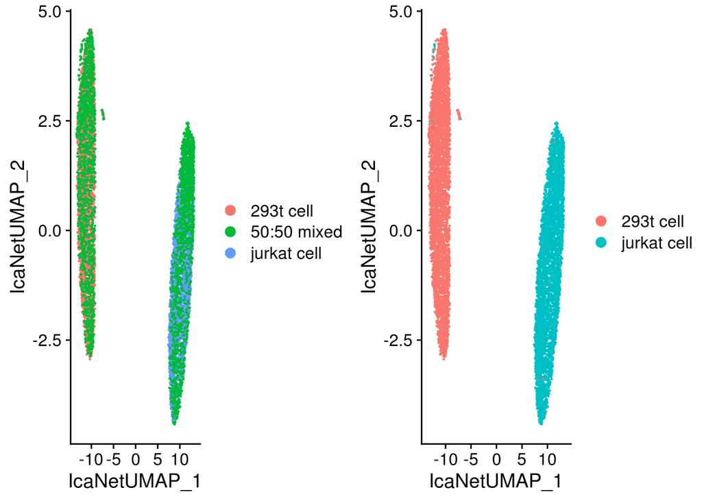

```r
p1 <- DimPlot(all.data, reduction = 'IcaNetUMAP', group.by = 'batch')
p2 <- DimPlot(all.data, reduction = 'IcaNetUMAP', group.by = 'celltype')
plot_grid(p1, p2)
```

As you could see, using module-cell activity matrix infered through ICAnet could correct the batch effects.